# Complain2012-Copy1

## Text Mining to Decipher Free-Response Consumer Complaints

### OBJECTIVE

The objective of this study is to identify clusters of vehicle related problem and associated year trends after 2012. Incidents representing two severity levels(fatal incidents and incidents involving injury) from the free response data in the NHTSA's vehicls owner's complaint database are analyzed using text mining approach.

### METHOD

**Vehicle Owner's Complaint Database**

##### **Table 1: Number and Percentage of cases in the Database organized by the 'Injury' and 'Deaths' field**

```python
table
```

|  | Injury and Death Involvement | Number of Cases | Proportion of the Database (%) |
| --- | --- | --- | --- |
| 0 | At least one death reported | 534 | 0.00121525 |
| 1 | No deaths and at least one injury reported | 11579 | 0.026351 |
| 2 | No injuries or deaths reported | 212408 | 0.483389 |
| 3 | No injuries reported, missing fatality data | 151 | 0.000343639 |
| 4 | At least one injury reported, missing fatality... | 4518 | 0.0102819 |
| 5 | No deaths reported, missing injury data | 78 | 0.000177509 |
| 6 | Missing both injury and fatality data | 210146 | 0.478241 |

**Data Preprocessing**

The description column of the database is preprocessed before creating clusters. The preprocessing is common in text mining and includes removing punctuation, stemming the words and removing the stopwords. Further, words greater than 2 characters were used in the analysis as there are some certain unnecesserary 2 character words which could have skewed the clusters.

After preprocessing the description part, a term-document matrix is created. In the term-document matrix, each row corresponds to a term in the corpus and each column to a complaint. The values in each cell represents frequency of a term in each row and in each complaint.

**Dimensionality reduction**

Term-Document matrix contains terms of low frequency which may not be of interest to us. Thus, it is necessary to reduce dimensionality of our term-document matrix. LSA provides an efficient way of identifying similar documents by reducing the dimensionality of the term-document matrix. Dimensionality reduction is achieved through Singular value decomposition performed on the term-document matrix.

### RESULTS

The clusters were made using Hierarchical Clustering Method. Clustering was stopped one step before a split occured that resulted in two different clusters with the same most frequent terms.

Cluster analysis identified eight clusters of fatal accidents and five clusters of incidents involving injury.

**Fatal Incidents**

From the time-trend graph, it can be noticed that recal has a increasing trend after 2014 which may be due to the fact that Vehicle Manufacturers started complying with NHTSA decision to recall all the defective models with faulty TAKATA airbags.

Analysis of the **Crash** cluster reveals that it is related to Tesla car crashes, especially Model S in the recent years. Out of the 13 complaints, TESLA alone was responsible for 13 deaths with no other manufacturer causing more than 2 deaths. Most of the complaints are related to suspension failures leading to wheel detachment and causing crash. There might be more deaths or injuries caused by faulty TESLA models which may not been been reported to NHTSA as TESLA made their customers sign Non-disclosure agreement. There are four instances of crashes due to Autopilot mode. Tesla's Autopilot mode has stirred a lot of controversy in the past year with the question being "Is Autopilot mode reliable?". However, in an investigation conducted by NTSB, there were no defects found in TESLA's autopilot mode of the car's involved in accidents. NTSB also concluded that Tesla car crash rate dropped by 40% after Autopilot mode was installed.

The time-trend graph of crash cluster shows that number of crashes are increasing over the past few years which may be the result of over-reliance on advanced technologies.

The **brake** cluster seems to represents sudden unintended acceleration problem which which might still be present in the cars. In 2009, unintended sudden acceleration problem was present prominently in Toyota vehicles followed by Ford vehicles. This issue seems to be the main cause of deaths in Toyota vehicles around 2014.

The **brake** cluster also represents incidents involving deaths caused by cars equipped with keyless ignition. This issue occured prominently in General Motor vehicles(Chevrolet, Buick, Pontiac) in which faulty ignition switch could shut off engine during a crash and thereby preventing airbags from inflating. In addition to GM vehicles, Lincoln(Ford luxury brand) vehicles were also affected causing 11 deaths. 10 out of 11 deaths due to keyless ignition issue in Lincoln vehicles occured in 2015.

The time-trend graph of brake cluster is concerning because number of accidents are increasing since 2016.

The seat cluster is related to issues with seatbelts, especially child safety seats.

The truck, passeng and contact cluster does not seem to be associated with any particular incident in the past 5 years. The deaths might be the result of any routine problems with the vehicles. However, one particular point of interest is that General Motor and Ford vehicles are associated with most deaths in these three clusters. Faulty airbags not inflating during a crash or contact with another vehicle might be the reason for deaths, but there has been no investigation about it.

The time-trend graphs for truck and contact cluster shows that most of the incidents occured around 2014-15 and they have been decreasing since.

##### **Fig 1: Wordclouds representing frequency of terms of in each cluster identified in Fatal incidents**

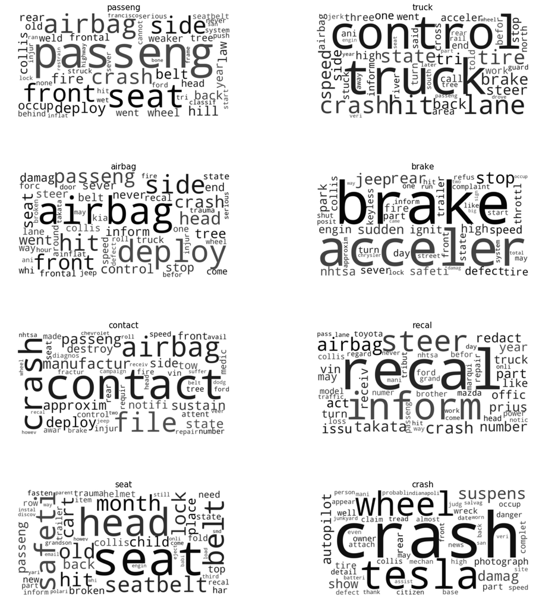

```python
wordclouds(death_clusters)
```

##### **Fig 2: The number of complaints in each cluster of fatal incidents**

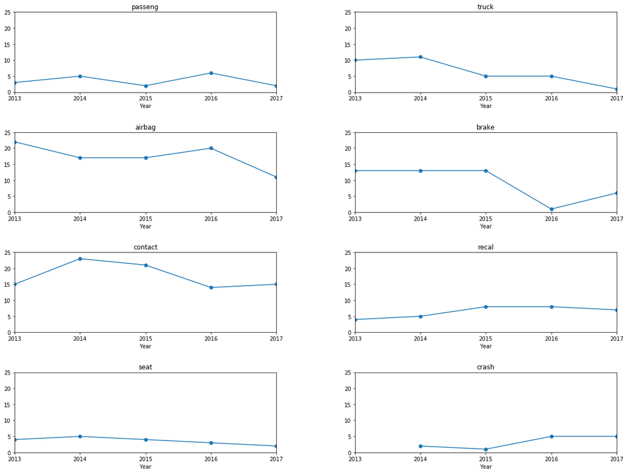

```python
yeartrend(death_clusters)
```

##### **Table 2: The most frequent terms in each cluster identified in Fatal Incidents**

```python
freq_table(death_clusters)
```

| groups | # of Complaints | Most Frequent Terms | Frequency of the Most Frequent Terms |
| --- | --- | --- | --- |
| 1 | 18 | [passeng, seat, airbag, front, side, crash, deploy, belt, fire, hill] | [37, 19, 18, 16, 15, 11, 9, 8, 8, 7] |
| 2 | 32 | [truck, control, lane, hit, crash, tire, state, speed, brake, tri] | [30, 27, 23, 22, 18, 16, 14, 11, 11, 10] |
| 3 | 87 | [airbag, deploy, side, hit, front, passeng, head, crash, seat, went] | [165, 103, 68, 53, 44, 40, 32, 29, 24, 20] |
| 4 | 46 | [brake, acceler, stop, rear, jeep, sudden, park, nhtsa, high, speed] | [38, 28, 26, 22, 22, 16, 13, 13, 12, 11] |
| 5 | 88 | [contact, crash, airbag, file, manufactur, passeng, deploy, approxim, sustain, state] | [239, 116, 86, 80, 79, 75, 72, 64, 62, 59] |
| 6 | 32 | [recal, inform, steer, airbag, crash, takata, number, prius, act, redact] | [69, 26, 25, 21, 16, 13, 11, 10, 10, 10] |
| 7 | 18 | [seat, head, safeti, belt, seatbelt, month, old, hit, lock, cart] | [31, 19, 9, 9, 9, 9, 8, 7, 7, 6] |
| 8 | 13 | [crash, tesla, wheel, suspens, damag, autopilot, show, photograph, tire, rear] | [41, 30, 20, 16, 11, 10, 9, 8, 8, 8] |

**Incidents involving Injury**

In the incidents involving injury, five clusters were made using Hierarchical clustering. Two clusters with the same most frequent term 'contact' were made if the dendrogram was cut at 6 clusters. So, clustering was stopped at 5 clusters.

**Airbag** cluster seems to represent TAKATA airbag issue, even though frequency of the term takata is low, it is same to assume that not every driver is going to mention the term 'takata' in their complaints.

The time-trend graph of airbag cluster reveals that number of injuries related to airbags have been decreasing over the past few years. This could be due to the fact that majority of the manufacturers have recalled the vehicles with faulty airbags.

The **Steer** cluster is associated with power steering issues with Ford vehicles. In these vehicles,some of the steering gear heat shield fasteners may have a surface finish with insufficient corrosion protection. According to Ford "the heat shield may corrode and detach from the steering gear — exposing the steering gear system to higher than expected temperatures". Ford recalled 4,23,000 vehicles in the year 2015 for the power steering issue. There are 23 injuries related to Ford vehicles associated with Steer cluster.

##### **Fig 4: Wordclouds representing frequency of terms of in each cluster identified in Incidents involving Injury**

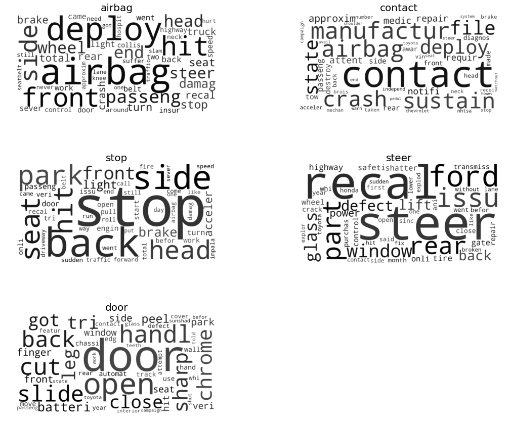

```python
wordclouds(injury_clusters)
```

##### **Fig 5: The number of complaints in each cluster of Incidents involving Injury**

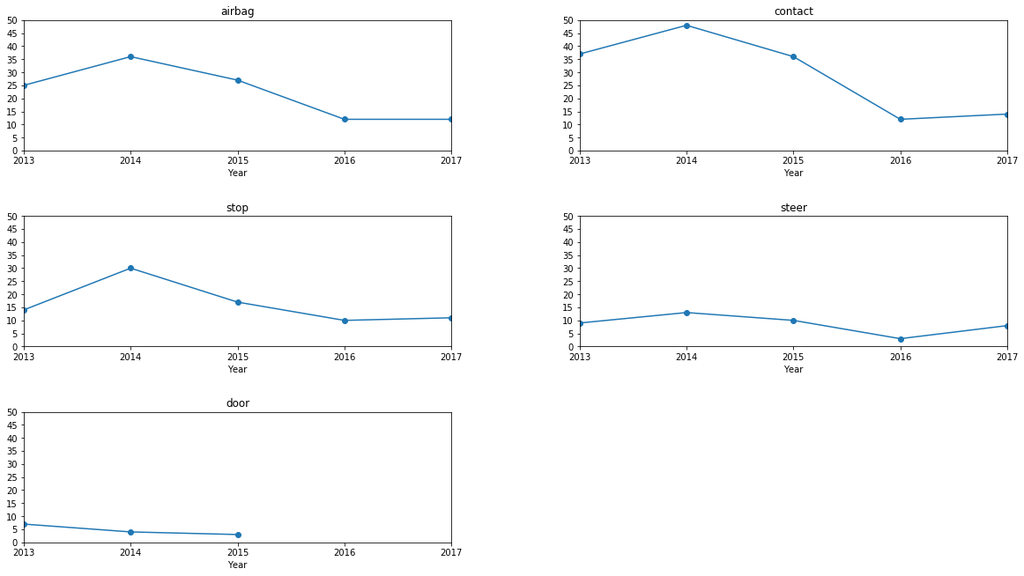

```python
yeartrend(injury_clusters)
```

##### **Table 3: The most frequent terms in each cluster identified in Incidents involving Injury**

```python
freq_table(injury_clusters)
```

| groups | # of Complaints | Most Frequent Terms | Frequency of the Most Frequent Terms |
| --- | --- | --- | --- |
| 1 | 114 | [airbag, deploy, hit, front, side, passeng, end, head, wheel, steer] | [209, 163, 105, 100, 87, 57, 51, 48, 47, 43] |
| 2 | 147 | [contact, manufactur, airbag, sustain, crash, deploy, file, state, approxim, medic] | [559, 149, 144, 133, 125, 116, 115, 111, 108, 98] |
| 3 | 82 | [stop, back, side, park, seat, hit, head, front, brake, light] | [65, 61, 47, 45, 44, 44, 40, 38, 38, 34] |
| 4 | 43 | [steer, recal, ford, issu, part, rear, window, glass, defect, back] | [30, 29, 28, 27, 26, 23, 22, 19, 18, 16] |
| 5 | 14 | [door, open, handl, cut, slide, back, chrome, sharp, close, tri] | [58, 21, 13, 12, 11, 11, 9, 9, 7, 7] |

##### **Normalized Frequency of complaints**

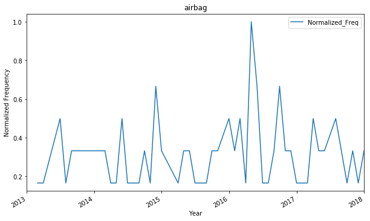

```python
## For airbag cluster in Fatality incidents
norm_freq(death_clusters)
```

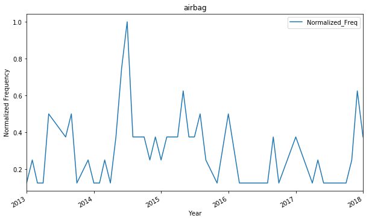

```python
# For airbag cluster in Incidents involving injury
norm_freq(injury_clusters)
```

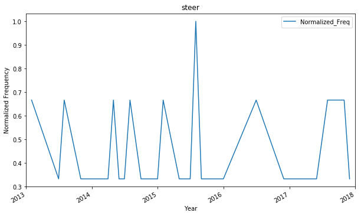

```python
# for steer cluster in Incidents involving Injury
norm_freq(injury_clusters)
```